# Assignment 2 - Hai(TA)’s solution

# Problem 2

Bivariate Inference (20 pts)

In this problem, the primary objectives are to numerically investigate the strength and significance of associations between MetS and predictor variables. In each case, provide the appropriate measure of association and report confidence intervals or p-values where needed. For statistical significance, use alpha=0.05.

## a.

Create a contingency (2x2) table to summarize the relationship MetS and race/ethnicity. Report the odds ratio (OR) of MetS in each race category versus White (reference level) and the corresponding 95% confidence interval. Which race/ethnicity levels are have significantly disparate odds of MetS versus the reference level?

```r
table(df$ethnicity)
```

```
##
##   0   1   2   3   4
## 546 780 527 340 119
```

- Hispanic vs. White

```r
df %>%
  select(mets.ind, ethnicity) %>%
  filter(ethnicity %in% c(1,0)) %>%
  janitor::tabyl(mets.ind, ethnicity)
```

```
##  mets.ind   0   1
##         0 212 307
##         1 334 473
```

```r
df %>%
  select(mets.ind, ethnicity) %>%
  filter(ethnicity %in% c(2,0)) %>%
  janitor::tabyl(mets.ind, ethnicity)
```

```
##  mets.ind   0   2
##         0 212 251
##         1 334 276
```

```r
df %>%
  select(mets.ind, ethnicity) %>%
  filter(ethnicity %in% c(0,1)) %>%
  mutate(
    mets.ind = factor(mets.ind, labels = c("No", "Yes")),
    ethnicity = factor(ethnicity, labels = c("Hispanic", "White"))
  ) %>%
    sjlabelled::var_labels(
    mets.ind = "MetS",
    ethnicity = "Race/Ethnic"
  ) %>%
  mutate(
    mets.ind = relevel(mets.ind, ref = "No"),
    ethnicity = relevel(ethnicity, ref = "White")
  ) %>%
  contingency(mets.ind~ethnicity)
```

```
##           Outcome
## Predictor  Yes  No
##   Hispanic 334 212
##   White    473 307
##
##              Outcome +    Outcome -      Total        Inc risk *        Odds
## Exposed +          334          212        546              61.2        1.58
## Exposed -          473          307        780              60.6        1.54
## Total              807          519       1326              60.9        1.55
##
## Point estimates and 95% CIs:
## -------------------------------------------------------------------
## Inc risk ratio                               1.01 (0.92, 1.10)
## Odds ratio                                   1.02 (0.82, 1.28)
## Attrib risk in exposed *                     0.53 (-4.80, 5.87)
## Attrib fraction in exposed (%)              0.87 (-8.20, 9.18)
## Attrib risk in population *                  0.22 (-4.10, 4.54)
## Attrib fraction in population (%)           0.36 (-3.32, 3.90)
## -------------------------------------------------------------------
## Uncorrected chi2 test that OR = 1: chi2(1) = 0.038 Pr>chi2 = 0.845
## Fisher exact test that OR = 1: Pr>chi2 = 0.864
##  Wald confidence limits
##  CI: confidence interval
##  * Outcomes per 100 population units
##
##  Measures of association strength:
##  The outcome risk among the exposed was 1.01 (95% CI 0.92 to 1.1) times greater than the outcome risk among the unexposed.
##
##  The outcome odds among the exposed was 1.02 (95% CI 0.82 to 1.28) times greater than the outcome odds among the unexposed.
##
##  Measures of effect in the exposed:
##  Exposure changed outcome risk in the exposed by 0.53 (95% CI -4.8 to 5.87) per 100 population units. 0.9% of outcomes in the exposed were attributable to exposure (95% CI -8.2% to 9.2%).
##
##  Number needed to treat for benefit (NNTB) and harm (NNTH):
##  The number needed to treat for one subject to benefit (NNTB) is 188 (NNTH 21 to infinity to NNTB 17).
##
##  Measures of effect in the population:
##  Exposure changed outcome risk in the population by 0.22 (95% CI -4.1 to 4.54) per 100 population units. 0.4% of outcomes in the population were attributable to exposure (95% CI -3.3% to 3.9%).
##
##
##  Pearson's Chi-squared test with Yates' continuity correction
##
## data:  dat
## X-squared = 0.019007, df = 1, p-value = 0.8903
```

Here, I created a function (if you are a SAS users, it can play a role as a macro). So the function with name of `cross.tab2x2` with 2 parameters in its argument: `racevalue` and `racegroupname` where I set the value default are $0$ and "Hispanic# for 2 parameters respectively.

```r
cross.tab2x2 <- function(racevalue=0, racegroupname="Hispanic"){
  df %>%
  select(mets.ind, ethnicity) %>%
  filter(ethnicity %in% c(racevalue,1)) %>%
  mutate(
    mets.ind = factor(mets.ind, labels = c("No", "Yes")),
    ethnicity = factor(ethnicity, labels = c("White", racegroupname))
  ) %>%
    var_labels(
    mets.ind = "MetS",
    ethnicity = "Race/Ethnic"
  ) %>%
  mutate(
    mets.ind = relevel(mets.ind, ref = "No"),
    ethnicity = relevel(ethnicity, ref = "White")
  ) %>%
  contingency(mets.ind~ethnicity)
}
```

We call function created above with changing value for parameters in the argument. For example, `cross.tab2x2(racevalue=2, racegroupname="Black")` would compare Black vs White in contingency 2x2 table

```r
cross.tab2x2(racevalue=2, racegroupname="Black")
```

```
##          Outcome
## Predictor Yes  No
##     Black 276 251
##     White 473 307
##
##              Outcome +    Outcome -      Total        Inc risk *        Odds
## Exposed +          276          251        527              52.4        1.10
## Exposed -          473          307        780              60.6        1.54
## Total              749          558       1307              57.3        1.34
##
## Point estimates and 95% CIs:
## -------------------------------------------------------------------
## Inc risk ratio                               0.86 (0.78, 0.95)
## Odds ratio                                   0.71 (0.57, 0.89)
## Attrib risk in exposed *                     -8.27 (-13.74, -2.80)
## Attrib fraction in exposed (%)              -15.79 (-27.85, -4.86)
## Attrib risk in population *                  -3.33 (-7.69, 1.02)
## Attrib fraction in population (%)           -5.82 (-9.78, -2.00)
## -------------------------------------------------------------------
## Uncorrected chi2 test that OR = 1: chi2(1) = 8.790 Pr>chi2 = 0.003
## Fisher exact test that OR = 1: Pr>chi2 = 0.004
##  Wald confidence limits
##  CI: confidence interval
##  * Outcomes per 100 population units
##
##  Measures of association strength:
##  The outcome risk among the exposed was 0.86 (95% CI 0.78 to 0.95) times less than the outcome risk among the unexposed.
##
##  The outcome odds among the exposed was 0.71 (95% CI 0.57 to 0.89) times less than the outcome odds among the unexposed.
##
##  Measures of effect in the exposed:
##  Exposure changed outcome risk in the exposed by -8.27 (95% CI -13.74 to -2.8) per 100 population units. -15.8% of outcomes in the exposed were attributable to exposure (95% CI -27.9% to -4.9%).
##
##  Number needed to treat for benefit (NNTB) and harm (NNTH):
##  The number needed to treat for one subject to be harmed (NNTH) is 12 (95% CI 36 to 7).
##
##  Measures of effect in the population:
##  Exposure changed outcome risk in the population by -3.33 (95% CI -7.69 to 1.02) per 100 population units. -5.8% of outcomes in the population were attributable to exposure (95% CI -9.8% to -2%).
##
##
##  Pearson's Chi-squared test with Yates' continuity correction
##
## data:  dat
## X-squared = 8.4551, df = 1, p-value = 0.00364
```

```r
cross.tab2x2(racevalue=3, racegroupname="Asian")
```

```
##          Outcome
## Predictor Yes  No
##     Asian 187 153
##     White 473 307
##
##              Outcome +    Outcome -      Total        Inc risk *        Odds
## Exposed +          187          153        340              55.0        1.22
## Exposed -          473          307        780              60.6        1.54
## Total              660          460       1120              58.9        1.43
##
## Point estimates and 95% CIs:
## -------------------------------------------------------------------
## Inc risk ratio                               0.91 (0.81, 1.01)
## Odds ratio                                   0.79 (0.61, 1.03)
## Attrib risk in exposed *                     -5.64 (-11.94, 0.66)
## Attrib fraction in exposed (%)              -10.26 (-23.27, 1.38)
## Attrib risk in population *                  -1.71 (-6.19, 2.77)
## Attrib fraction in population (%)           -2.91 (-6.22, 0.31)
## -------------------------------------------------------------------
## Uncorrected chi2 test that OR = 1: chi2(1) = 3.113 Pr>chi2 = 0.078
## Fisher exact test that OR = 1: Pr>chi2 = 0.086
##  Wald confidence limits
##  CI: confidence interval
##  * Outcomes per 100 population units
##
##  Measures of association strength:
##  The outcome risk among the exposed was 0.91 (95% CI 0.81 to 1.01) times less than the outcome risk among the unexposed.
##
##  The outcome odds among the exposed was 0.79 (95% CI 0.61 to 1.03) times less than the outcome odds among the unexposed.
##
##  Measures of effect in the exposed:
##  Exposure changed outcome risk in the exposed by -5.64 (95% CI -11.94 to 0.66) per 100 population units. -10.3% of outcomes in the exposed were attributable to exposure (95% CI -23.3% to 1.4%).
##
##  Number needed to treat for benefit (NNTB) and harm (NNTH):
##  The number needed to treat for one subject to be harmed (NNTH) is 18 (NNTH 8 to infinity to NNTB 151).
##
##  Measures of effect in the population:
##  Exposure changed outcome risk in the population by -1.71 (95% CI -6.19 to 2.77) per 100 population units. -2.9% of outcomes in the population were attributable to exposure (95% CI -6.2% to 0.3%).
##
##
##  Pearson's Chi-squared test with Yates' continuity correction
##
## data:  dat
## X-squared = 2.8845, df = 1, p-value = 0.08944
```

```r
cross.tab2x2(racevalue=4, racegroupname="Multi-Racial")
```

```
##               Outcome
## Predictor      Yes  No
##   Multi-Racial  63  56
##   White        473 307
##
##              Outcome +    Outcome -      Total        Inc risk *        Odds
## Exposed +           63           56        119              52.9        1.12
## Exposed -          473          307        780              60.6        1.54
## Total              536          363        899              59.6        1.48
##
## Point estimates and 95% CIs:
## -------------------------------------------------------------------
## Inc risk ratio                               0.87 (0.73, 1.04)
## Odds ratio                                   0.73 (0.50, 1.08)
## Attrib risk in exposed *                     -7.70 (-17.30, 1.90)
## Attrib fraction in exposed (%)              -14.54 (-36.94, 4.19)
## Attrib risk in population *                  -1.02 (-5.71, 3.68)
## Attrib fraction in population (%)           -1.71 (-3.89, 0.42)
## -------------------------------------------------------------------
## Uncorrected chi2 test that OR = 1: chi2(1) = 2.543 Pr>chi2 = 0.111
## Fisher exact test that OR = 1: Pr>chi2 = 0.132
##  Wald confidence limits
##  CI: confidence interval
##  * Outcomes per 100 population units
##
##  Measures of association strength:
##  The outcome risk among the exposed was 0.87 (95% CI 0.73 to 1.04) times less than the outcome risk among the unexposed.
##
##  The outcome odds among the exposed was 0.73 (95% CI 0.5 to 1.08) times less than the outcome odds among the unexposed.
##
##  Measures of effect in the exposed:
##  Exposure changed outcome risk in the exposed by -7.7 (95% CI -17.3 to 1.9) per 100 population units. -14.5% of outcomes in the exposed were attributable to exposure (95% CI -36.9% to 4.2%).
##
##  Number needed to treat for benefit (NNTB) and harm (NNTH):
##  The number needed to treat for one subject to be harmed (NNTH) is 13 (NNTH 6 to infinity to NNTB 53).
##
##  Measures of effect in the population:
##  Exposure changed outcome risk in the population by -1.02 (95% CI -5.71 to 3.68) per 100 population units. -1.7% of outcomes in the population were attributable to exposure (95% CI -3.9% to 0.4%).
##
##
##  Pearson's Chi-squared test with Yates' continuity correction
##
## data:  dat
## X-squared = 2.2329, df = 1, p-value = 0.1351
```

Other way to process data:

```r
df %>%
  mutate(ethnicity = factor(ethnicity, levels =  c(1, 0))) %>%
  contingency(mets.ind ~ ethnicity)
```

```
##          Outcome
## Predictor   1   0
##         0 334 212
##         1 473 307
##
##              Outcome +    Outcome -      Total        Inc risk *        Odds
## Exposed +          334          212        546              61.2        1.58
## Exposed -          473          307        780              60.6        1.54
## Total              807          519       1326              60.9        1.55
##
## Point estimates and 95% CIs:
## -------------------------------------------------------------------
## Inc risk ratio                               1.01 (0.92, 1.10)
## Odds ratio                                   1.02 (0.82, 1.28)
## Attrib risk in exposed *                     0.53 (-4.80, 5.87)
## Attrib fraction in exposed (%)              0.87 (-8.20, 9.18)
## Attrib risk in population *                  0.22 (-4.10, 4.54)
## Attrib fraction in population (%)           0.36 (-3.32, 3.90)
## -------------------------------------------------------------------
## Uncorrected chi2 test that OR = 1: chi2(1) = 0.038 Pr>chi2 = 0.845
## Fisher exact test that OR = 1: Pr>chi2 = 0.864
##  Wald confidence limits
##  CI: confidence interval
##  * Outcomes per 100 population units
##
##  Measures of association strength:
##  The outcome risk among the exposed was 1.01 (95% CI 0.92 to 1.1) times greater than the outcome risk among the unexposed.
##
##  The outcome odds among the exposed was 1.02 (95% CI 0.82 to 1.28) times greater than the outcome odds among the unexposed.
##
##  Measures of effect in the exposed:
##  Exposure changed outcome risk in the exposed by 0.53 (95% CI -4.8 to 5.87) per 100 population units. 0.9% of outcomes in the exposed were attributable to exposure (95% CI -8.2% to 9.2%).
##
##  Number needed to treat for benefit (NNTB) and harm (NNTH):
##  The number needed to treat for one subject to benefit (NNTB) is 188 (NNTH 21 to infinity to NNTB 17).
##
##  Measures of effect in the population:
##  Exposure changed outcome risk in the population by 0.22 (95% CI -4.1 to 4.54) per 100 population units. 0.4% of outcomes in the population were attributable to exposure (95% CI -3.3% to 3.9%).
##
##
##  Pearson's Chi-squared test with Yates' continuity correction
##
## data:  dat
## X-squared = 0.019007, df = 1, p-value = 0.8903
```

To sum up, the odds ratio (OR) of MetS in each race category versus White (reference level) and the corresponding 95% confidence interval:

| Other race vs White (ref.) | OR (95% CI) |
| --- | --- |
| Hispanic | 1.02 (0.82, 1.28) |
| Black | 0.71 (0.57, 0.89) |
| Asian | 0.79 (0.61, 1.03) |
| Multiracial | 0.73 (0.50, 1.08) |

## b.

Using t-tests or ANOVA, determine the significance of the association between MetS and (i) sleep duration; (ii) fasting blood glucose. In each case, state your conclusions.

```r
t.test(sleep ~ mets.ind, data = df, alternative = "two.sided", paired = FALSE, var.equal = FALSE)
```

```
##
##  Welch Two Sample t-test
##
## data:  sleep by mets.ind
## t = 1.6096, df = 2189.7, p-value = 0.1076
## alternative hypothesis: true difference in means is not equal to 0
## 95 percent confidence interval:
##  -0.01825301  0.18547012
## sample estimates:
## mean in group 0 mean in group 1
##        7.968080        7.884471
```

```r
t.test(glu ~ mets.ind, data = df, alternative = "two.sided", paired = FALSE, var.equal = FALSE)
```

```
##
##  Welch Two Sample t-test
##
## data:  glu by mets.ind
## t = -17.115, df = 1704.8, p-value < 2.2e-16
## alternative hypothesis: true difference in means is not equal to 0
## 95 percent confidence interval:
##  -27.74739 -22.04169
## sample estimates:
## mean in group 0 mean in group 1
##        100.8315        125.7260
```

## c.

Use an appropriate logistic regression model to estimate the OR and 95% confidence interval for a 1 unit increase in fasting glucose. Briefly describe the effect of fasting blood glucose on the odds of MetS (is it protective or a risk factor? Is the association significant?).

```r
mod <- glm(mets.ind ~ glu, family = binomial, data=df)
summary(mod)
```

```
##
## Call:
## glm(formula = mets.ind ~ glu, family = binomial, data = df)
##
## Deviance Residuals:
##    Min      1Q  Median      3Q     Max
## -5.855  -1.003   0.148   1.061   2.395
##
## Coefficients:
##              Estimate Std. Error z value Pr(>|z|)
## (Intercept) -5.682832   0.390520  -14.55   <2e-16 ***
## glu          0.054212   0.003709   14.61   <2e-16 ***
## ---
## Signif. codes:  0 '***' 0.001 '**' 0.01 '*' 0.05 '.' 0.1 ' ' 1
##
## (Dispersion parameter for binomial family taken to be 1)
##
##     Null deviance: 2932.7  on 2124  degrees of freedom
## Residual deviance: 2504.6  on 2123  degrees of freedom
##   (187 observations deleted due to missingness)
## AIC: 2508.6
##
## Number of Fisher Scoring iterations: 6
```

```r
## odds ratios only
exp(coef(mod))
```

```
## (Intercept)         glu
## 0.003403904 1.055708458
```

```r
## odds ratios and 95% CI
exp(cbind(OR = coef(mod), confint(mod)))
```

```
##                      OR       2.5 %      97.5 %
## (Intercept) 0.003403904 0.001553569 0.007180578
## glu         1.055708458 1.048265777 1.063618991
```

# Problem 3

Multivariate Analysis (10 pts)

In this problem, your task is to investigate the relationship between MetS (outcome) and sleep duration (primary exposure) while adjusting for **possible confounding variables**.

## a.

In Smiley et al., the authors show a curvilinear (quadratic) relationship between MetS prevalence and sleep duration. Reproduce similar results using the following steps:

### (i)

Regress MetS on sleep duration using logistic regression and include both linear and quadratic terms (e.g., glm(Y ~ X + I(X^2), data=df);

Check missing of response and covariates:

```r
sum(is.na(df$sleep))
```

```
## [1] 0
```

```r
sum(is.na(df$ageCat))
```

```
## [1] 0
```

```r
sum(is.na(df$ethnicity))
```

```
## [1] 0
```

```r
sum(is.na(df$mets.ind)) #none NA of response and covariates
```

```
## [1] 0
```

```r
# convert a numeric of ethnicity to factor
df$ethnicity <- factor(df$ethnicity, levels=c(0,1,2,3,4),
                    labels=c("Hispanic", "White", "Black", "Asian", "Multiracial"))
df$ethnicity <- relevel(df$ethnicity, ref = "White")

fit <- glm(
  mets.ind ~ sleep + I(sleep^2) + ageCat + ethnicity,
  family = binomial(),
  data = df)
summary(fit)
```

```
##
## Call:
## glm(formula = mets.ind ~ sleep + I(sleep^2) + ageCat + ethnicity,
##     family = binomial(), data = df)
##
## Deviance Residuals:
##     Min       1Q   Median       3Q      Max
## -2.1205  -0.8475   0.6092   0.7967   1.9934
##
## Coefficients:
##                      Estimate Std. Error z value Pr(>|z|)
## (Intercept)           0.72108    1.46638   0.492  0.62290
## sleep                -0.51069    0.37018  -1.380  0.16772
## I(sleep^2)            0.02943    0.02335   1.260  0.20753
## ageCat30-39           0.61143    0.18937   3.229  0.00124 **
## ageCat40-49           1.42238    0.18572   7.659 1.88e-14 ***
## ageCat50-59           2.09873    0.18158  11.558  < 2e-16 ***
## ageCat60-69           2.82106    0.18365  15.361  < 2e-16 ***
## ageCat70+             2.97974    0.19489  15.289  < 2e-16 ***
## ethnicityHispanic     0.25339    0.13263   1.910  0.05607 .
## ethnicityBlack       -0.34531    0.13197  -2.617  0.00888 **
## ethnicityAsian       -0.20008    0.14915  -1.342  0.17975
## ethnicityMultiracial  0.08798    0.22599   0.389  0.69706
## ---
## Signif. codes:  0 '***' 0.001 '**' 0.01 '*' 0.05 '.' 0.1 ' ' 1
##
## (Dispersion parameter for binomial family taken to be 1)
##
##     Null deviance: 3150.7  on 2311  degrees of freedom
## Residual deviance: 2590.7  on 2300  degrees of freedom
## AIC: 2614.7
##
## Number of Fisher Scoring iterations: 4
```

### (ii)

use the predict() function to predict the prevalence of MetS for each subject and append it to the data frame;

```r
mets.predict <- fit %>% predict(df, type = "response")
#predict(fit, data=df, type="response")
#mets.predict <- fit$fitted.values

df$mets.predict <- mets.predict

#mets.predict <- fit %>% predict(df, type = "response", se.fit=TRUE)
```

```r
psych::describe(df$mets.predict)
```

```
##    vars    n mean   sd median trimmed  mad  min  max range  skew kurtosis se
## X1    1 2312 0.58 0.24   0.65    0.59 0.25 0.14 0.89  0.76 -0.48    -1.26  0
```

3. use ggplot to graph the relationship between predicted MetS prevalence and sleep duration. Do the results appear similar to those in Smiley et al., Figure 1? Briefly explain why or why not.

Note: logistic regression and predict can give strange results in the presence of missing values. Therefore, it is strongly recommended that you filter out observations that are missing either MetS or sleep duration prior to modeling.

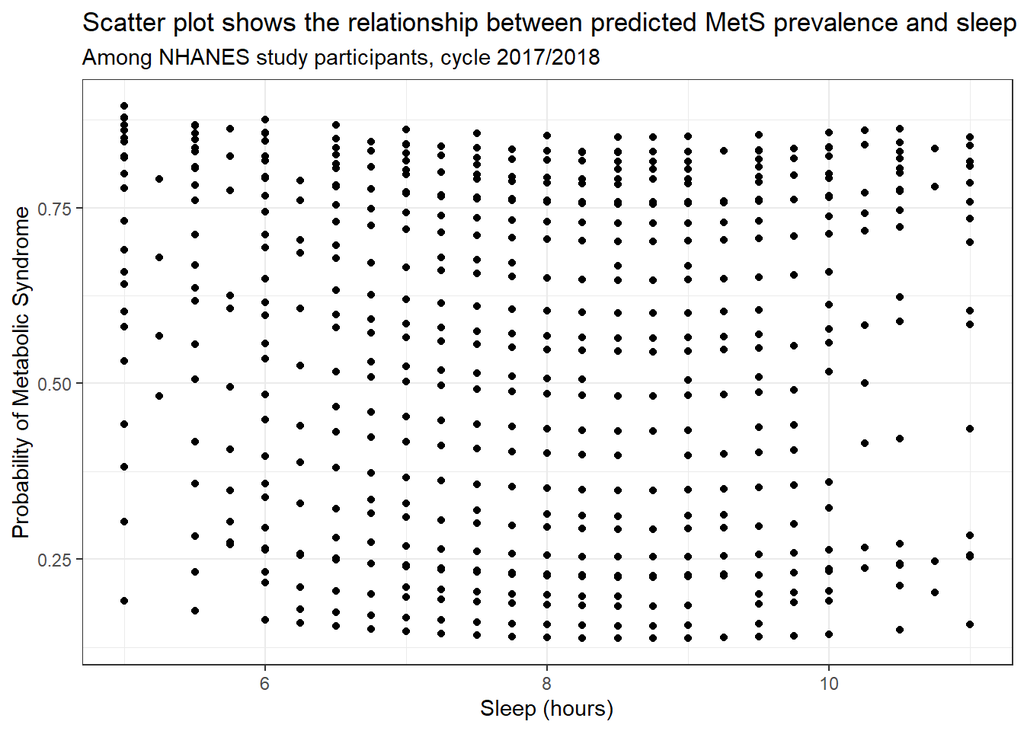

```r
ggplot(df, aes(x=sleep, y=mets.predict)) +
  geom_point() +
  theme_bw() +
  ylab("Probability of Metabolic Syndrome") + xlab("Sleep (hours)") +
  labs(title="Scatter plot shows the relationship between predicted MetS prevalence and sleep duration", subtitle= "Among NHANES study participants, cycle 2017/2018")
```

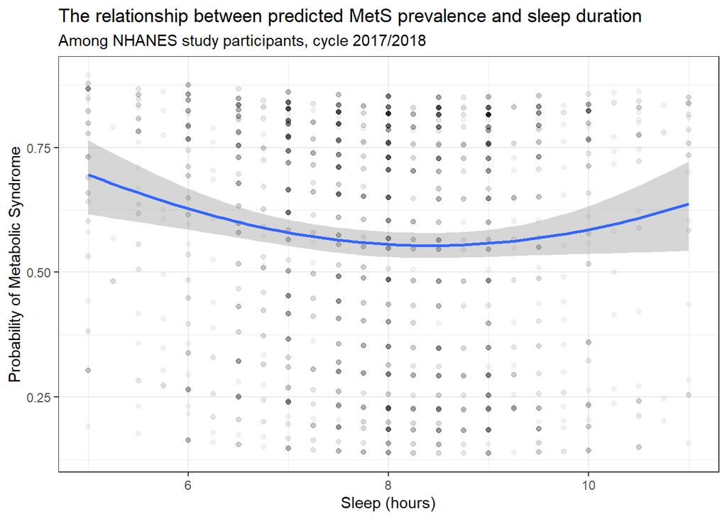

[output not shown]

```r
ggplot(df, aes(x=sleep, y=mets.predict)) +
  geom_point(alpha = 0.05) + # Varying alpha (points transparent) is useful for large datasets
  theme_bw() +
  stat_smooth(method = "glm",
    method.args = list(family = "binomial"),
    formula = y ~ x + I(x^2), # can we add ageCat/ethinicity: nope!!!
    se = TRUE) + # can switch to se = FALSE
    ylab("Probability of Metabolic Syndrome") + xlab("Sleep (hours)") +
    labs(title="The relationship between predicted MetS prevalence and sleep duration", subtitle= "Among NHANES study participants, cycle 2017/2018")
```

A convenient way (why this one correct?? not sure):

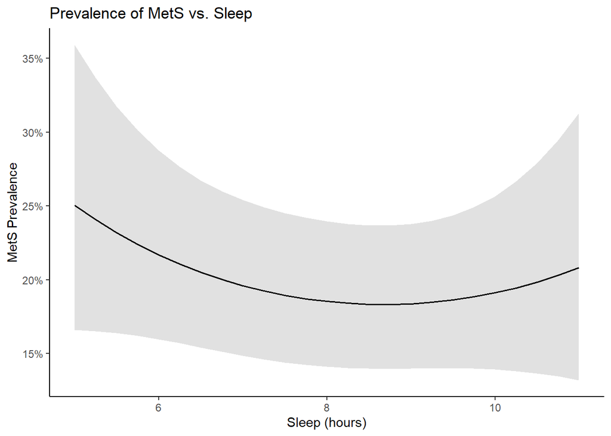

```r
sjPlot::plot_model(fit, type = "pred", terms = "sleep") +
  theme_classic() + xlab("Sleep (hours)") + ylab("MetS Prevalence") +
  labs(title = "Prevalence of MetS vs. Sleep")
```

## b.

Bonus question (optional): Repeat the above analysis and additionally include a ribbon around the plotted line to denote the 95% confidence interval. The predict function can be used to obtain confidence intervals and the geom_ribbon function can be used to graph them.

```r
mets.predict.w.se <- fit %>% predict(df, type = "response", se.fit=TRUE, level = 0.95)
```

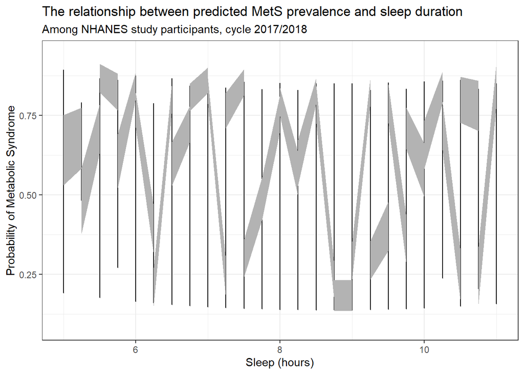

```r
ggplot(df, aes(x=sleep, y=mets.predict.w.se$fit)) +
  theme_bw() +
  geom_line() +
  geom_ribbon(aes(ymin = mets.predict - 1.96*mets.predict.w.se$se.fit, ymax = mets.predict + 1.96*mets.predict.w.se$se.fit), fill = "grey70") +
    ylab("Probability of Metabolic Syndrome") + xlab("Sleep (hours)") +
    labs(title="The relationship between predicted MetS prevalence and sleep duration", subtitle= "Among NHANES study participants, cycle 2017/2018")
```

Why we got the plot like that? Basically, let look at the data so that we can understand:

```r
library(kableExtra)
df %>% select(id, mets.ind,sleep, ageCat, ethnicity, mets.predict) %>%
  mutate(up.pred = mets.predict.w.se$fit + 1.96*mets.predict.w.se$se.fit,
         l.pred = mets.predict.w.se$fit - 1.96*mets.predict.w.se$se.fit) %>%
  top_n(20)
```

```
##        id mets.ind sleep ageCat ethnicity mets.predict   up.pred    l.pred
## 1   93754        1  7.00    70+  Hispanic    0.8607639 0.9011728 0.8203550
## 2   94918        0  7.00    70+  Hispanic    0.8607639 0.9011728 0.8203550
## 3   95041        1  6.00  60-69  Hispanic    0.8570522 0.8978481 0.8162564
## 4   95073        1  6.50    70+  Hispanic    0.8674175 0.9072514 0.8275835
## 5   95098        1  6.00  60-69  Hispanic    0.8570522 0.8978481 0.8162564
## 6   95338        1  7.00    70+  Hispanic    0.8607639 0.9011728 0.8203550
## 7   95590        1  5.00  60-69  Hispanic    0.8784609 0.9295312 0.8273906
## 8   95838        1  7.00    70+  Hispanic    0.8607639 0.9011728 0.8203550
## 9   96639        0  5.00    70+  Hispanic    0.8944112 0.9416562 0.8471663
## 10  96834        0  6.00    70+  Hispanic    0.8754137 0.9158526 0.8349748
## 11  97023        1  6.50    70+  Hispanic    0.8674175 0.9072514 0.8275835
## 12  97516        1  5.00  60-69  Hispanic    0.8784609 0.9295312 0.8273906
## 13  98106        1  6.00    70+  Hispanic    0.8754137 0.9158526 0.8349748
## 14  98679        1  6.00  60-69  Hispanic    0.8570522 0.8978481 0.8162564
## 15  98940        1  6.00  60-69  Hispanic    0.8570522 0.8978481 0.8162564
## 16  99535        1  6.00    70+  Hispanic    0.8754137 0.9158526 0.8349748
## 17  99895        1  7.00    70+  Hispanic    0.8607639 0.9011728 0.8203550
## 18 100834        1  7.00    70+  Hispanic    0.8607639 0.9011728 0.8203550
## 19 101193        0  5.75  60-69  Hispanic    0.8620271 0.9045680 0.8194862
## 20 101478        0  6.00  60-69  Hispanic    0.8570522 0.8978481 0.8162564
## 21 101679        1  6.00  60-69  Hispanic    0.8570522 0.8978481 0.8162564
## 22 101888        0  6.00  60-69  Hispanic    0.8570522 0.8978481 0.8162564
## 23 102618        0  6.00    70+  Hispanic    0.8754137 0.9158526 0.8349748
## 24 102629        1  6.00    70+  Hispanic    0.8754137 0.9158526 0.8349748
## 25 102863        1  5.50  60-69  Hispanic    0.8672799 0.9121646 0.8223952
```

Again, with the logistic regression with multiple covariates, we would have a large combination of all type of covariates equivalent to each sleep hour.